# quiz 2

#### (b) 시각화를 통하여 `wind`와 `pressure`의 관계를 설명하시오. [4점]

- `geom_point`와 `geom_smooth`를 사용하여 시각화하시오. [2점]
- plot에 대한 해석을 서술하시오. [2점]

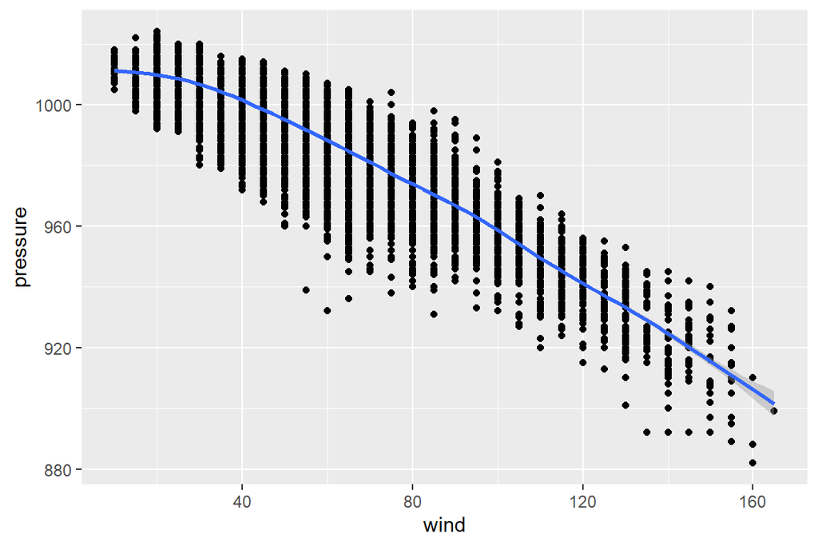

```r
ggplot(storms, aes(wind, pressure)) +
  geom_point() +
  geom_smooth()
```

```r
#태풍의 최대 풍속이 높을수록, 태풍 중심의 기압이 낮아진다.
#음의 상관관계를 보인다.
```

#### (c) 시각화를 통하여 월별 `wind`의 분포에 대해 설명하시오. [4점]

- `geom_boxplot`을 사용하여 시각화하시오. [2점]
- plot에 대한 해석을 서술하시오. [2점]

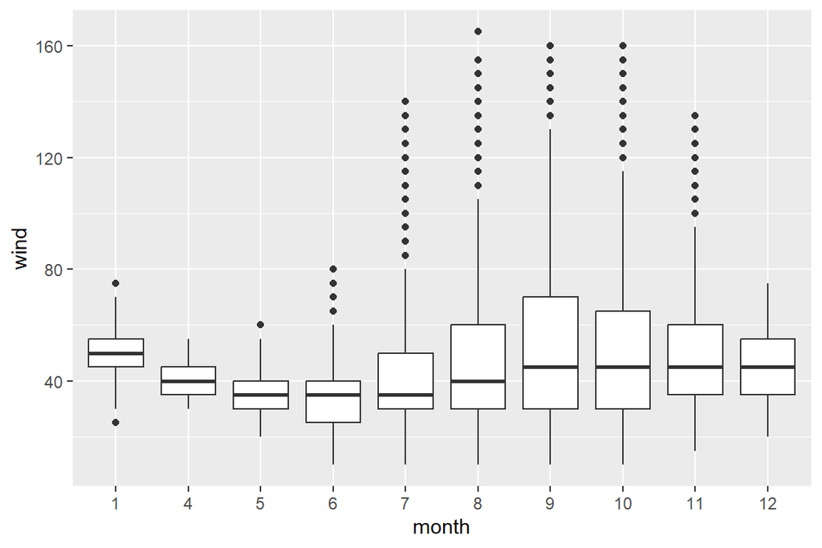

```r
ggplot(storms, aes(as.factor(month), wind)) +
  geom_boxplot() +
  xlab("month")
```

```r
#2, 3월에는 태풍이 없었다.
#가장 큰 풍속은 8월에 존재했고, 평균적인 풍속은 1월이 제일 높다.
```

#### (d) 1975년에 발생한 태풍 중 지속 시간이 가장 긴 3개의 태풍을 찾아서 이름과 지속 시간을 table로 출력하시오. [7점]

- 하나의 행마다 태풍은 6시간이 지속된다고 가정하며, 지속시간의 단위는 시간으로 계산하시오.
- Single pipeline으로 작성하시오. [2점]

```r
storms %>%
  filter(year == 1975) %>%
  count(name, month, day) %>%
  group_by(name) %>%
  summarise(duration = sum(n) * 6) %>%
  arrange(desc(duration)) %>%
  head(3)
```

```
## # A tibble: 3 × 2
##   name     duration
##   <chr>       <dbl>
## 1 Eloise        276
## 2 Gladys        276
## 3 Caroline      198
```

#### (e) (d)에서 찾은 3개의 태풍의 진행 경로를 시각화하고자 한다. 다음의 조건을 참고하여 아래의 그래프를 재현하시오. [10점]

- 지도는 `maps` 패키지의 `world` 데이터를 사용한다. 육지의 색은 `gray95`, 경계선의 색은 `gray70`으로 설정한다. [2점] (Hint : `map_data("world")`)
- 위도, 경도를 이용하여 태풍의 진행 경로를 표시하시오. 각 태풍의 진행 경로는 색을 통해 구분하며, 태풍의 풍속을 원의 크기로 나타낸다. [4점]
- 투명도를 적절하게 조절하시오. [1점]
- 지도를 다음 조건에 맞게 확대하시오. (`longitude` : -150 ~ 0, `latitude` : 0 ~ 80) [1점]
- x축은 “Longitude”, y축은 “Latitude”, 제목은 “Path of storms”로 설정하시오. [1점]
- 배경테마는 black&white (bw)를 사용한다. [1점]

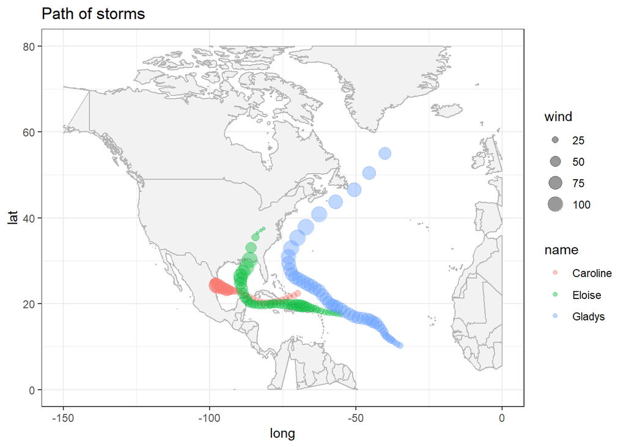

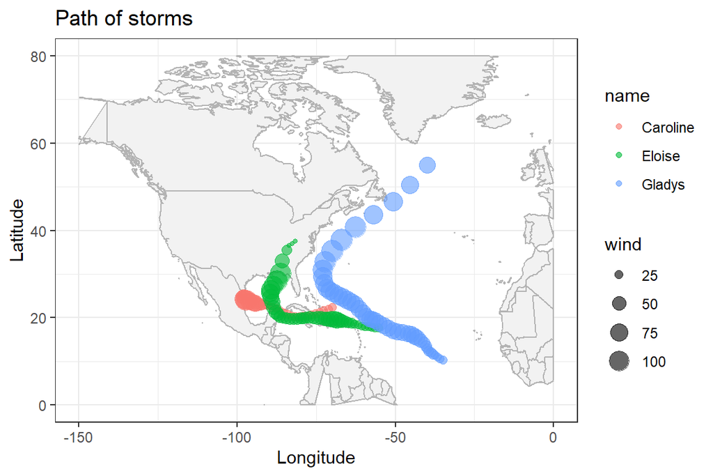

```r
target_storm <- storms %>%
  filter(year == 1975, name %in% c("Eloise", "Gladys", "Caroline"))

world <- map_data("world")

ggplot(world, aes(long, lat)) +
  geom_polygon(aes(group = group), fill = "gray95", colour = "gray70") +
  geom_point(data = target_storm, aes(size = wind, color = name), alpha = 0.6) +
  xlim(c(-150, 0)) +
  ylim(c(0, 80)) +
  labs(title = "Path of storms", x = "Longitude", y = "Latitude") +
  theme_bw()
```

### Problem 3

`palmerpenguins` 패키지의 `penguins` 데이터를 이용하는 문제이며, 주요 변수에 대한 설명은 다음과 같다.

- `species` : 펭귄의 종
- `island` : 펭귄의 서식지
- `bill_length_mm` : 부리의 길이 (mm)
- `bill_depth_mm` : 부리의 두께 (mm)

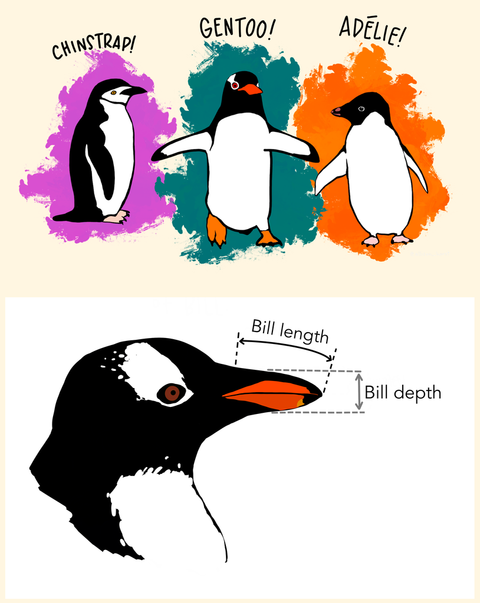

#### (a) `penguins` 데이터에서 결측치가 존재하는 행을 제거하고 제거된 행의 개수를 구하시오. [3점]

- 결측치가 제거된 데이터를 `penguins_clean`에 저장하고 `head()`를 이용하여 첫 10개의 행을 출력하시오. [2점]
- 제거된 행의 개수를 출력하시오. [1점]

```r
penguins_clean <- na.omit(penguins)
head(penguins_clean, 10)
```

```
## # A tibble: 10 × 8
##    species island    bill_length_mm bill_depth_mm flipper_length_mm body_mass_g
##    <fct>   <fct>              <dbl>         <dbl>             <int>       <int>
##  1 Adelie  Torgersen           39.1          18.7               181        3750
##  2 Adelie  Torgersen           39.5          17.4               186        3800
##  3 Adelie  Torgersen           40.3          18                 195        3250
##  4 Adelie  Torgersen           36.7          19.3               193        3450
##  5 Adelie  Torgersen           39.3          20.6               190        3650
##  6 Adelie  Torgersen           38.9          17.8               181        3625
##  7 Adelie  Torgersen           39.2          19.6               195        4675
##  8 Adelie  Torgersen           41.1          17.6               182        3200
##  9 Adelie  Torgersen           38.6          21.2               191        3800
## 10 Adelie  Torgersen           34.6          21.1               198        4400
## # ℹ 2 more variables: sex <fct>, year <int>
```

```r
nrow(penguins) - nrow(penguins_clean) #제거된 행의 개수
```

```
## [1] 11
```

#### (b) `penguins_clean` 데이터를 이용하여 아래의 그래프를 재현하시오. [7점]

- 각 종의 개체수를 서식지 별로 구분하여 나타내는 bar plot을 그리시오. [4점]
- 각 종의 개체수를 bar plot에 숫자로 표시하시오. [2점]
- 그래프의 제목은 “Distribution of Species on Different Islands”, x축은 “species”, y축은 “count”로 설정하시오. [1점]

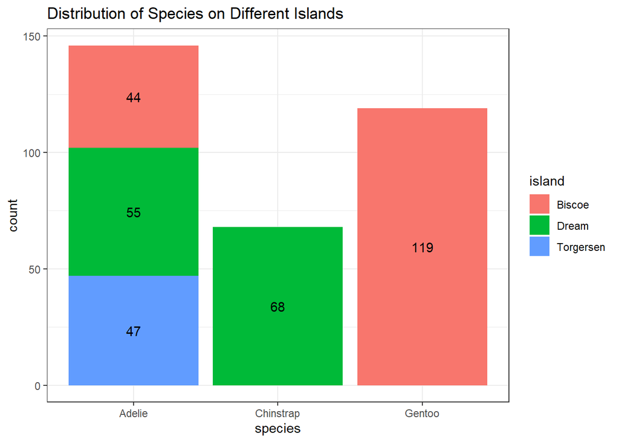

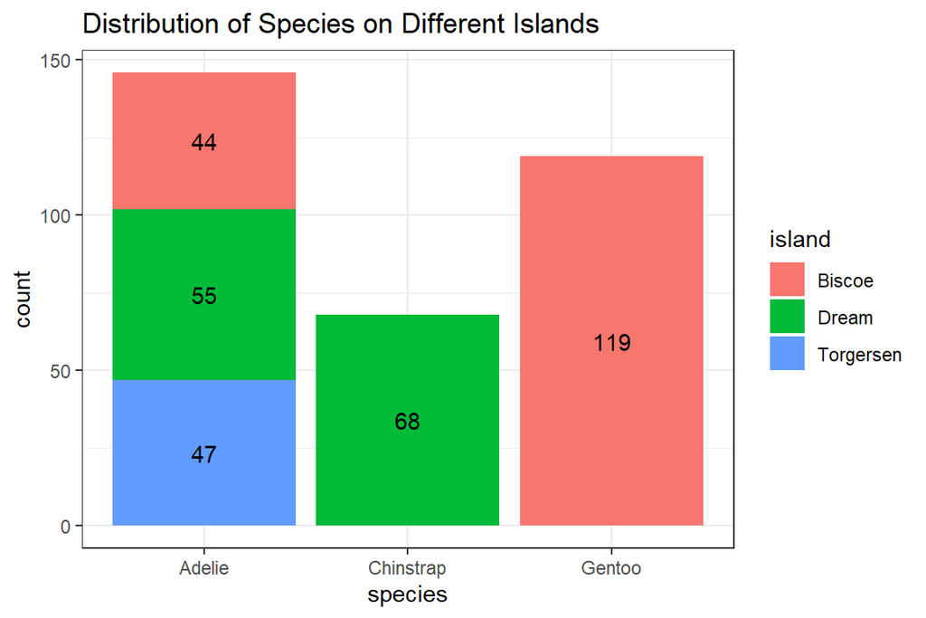

```r
ggplot(penguins_clean, aes(x = species, fill = island)) +
  geom_bar() +
  geom_text(
    aes(label = after_stat(count)),
    stat = "count",
    position =  position_stack(vjust = 0.5)
  ) +
  labs(
    title = "Distribution of Species on Different Islands",
    x = "species",
    y = "count"
  ) +
  theme_bw()
```

#### (c) `bill_length_mm`과 `bill_depth_mm`의 관계를 시각화를 통해 알아보고자 한다. 다음의 조건을 따라 2개의 산점도를 그리고 해석을 서술하시오. [그림 8점 + 해석 4점]

그림 1

- `penguins_clean` 데이터를 이용하여 `bill_length_mm`과 `bill_depth_mm`의 산점도를 그리시오. [2점]
- `geom_smooth`의 `method = "lm"` 옵션을 활용하여 회귀직선을 그리시오. [1점]
- x축은 “Length”, y축은 “Depth”, 제목은 “Scatter plot of Bill length and Bill depth”로 설정하시오. [1점]

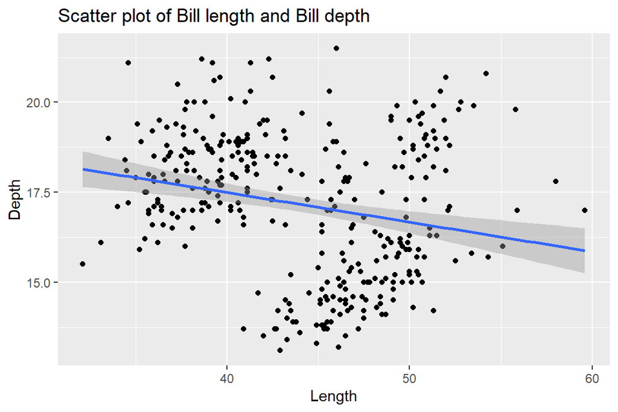

```r
ggplot(penguins_clean, aes(bill_length_mm, bill_depth_mm)) +
  geom_point() +
  geom_smooth(method = "lm") +
  labs(
    title = "Scatter plot of Bill length and Bill depth",
    x = "Length",
    y = "Depth"
  )
```

그림 2

- 종에 따라 색을 다르게하여 `bill_length_mm`과 `bill_depth_mm`의 산점도와 회귀직선을 다시 그리시오. [3점]
- 축과 제목은 그림 1과 동일하게 설정하시오. [1점]

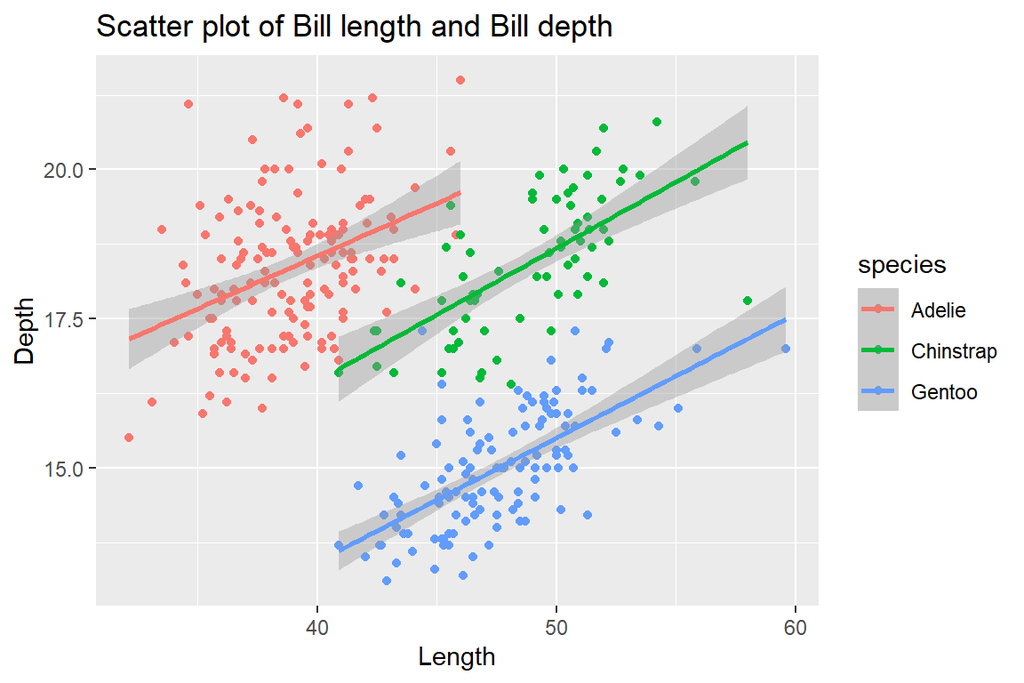

```r
ggplot(penguins_clean, aes(bill_length_mm, bill_depth_mm, color = species)) +
  geom_point() +
  geom_smooth(method = "lm") +
  labs(
    title = "Scatter plot of Bill length and Bill depth",
    x = "Length",
    y = "Depth"
  )
```

```r
#심슨의 역설
```